# Statistics Fundamentals

**Statistics** is usually defined as the science of drawing conclusions in the presence of uncertainty. It is most useful in the collection, analysis, and interpretation of **data**. This discipline provides us with the fundamental principles that allow us to extract and understand that information. It also provides us with the necessary tools to verify the quality of our data.

[figure not shown]

Statistics has two branches:

- **Descriptive Statistics**: Calulating the statistical parameters that describe the studied dataset. Some of the tools it uses are graphs, frequency measurements, centralization measurements, position measurements, dispersion measurements, among others. If these terms are unfamiliar to you, don't worry - we'll cover them soon.

[figure not shown]

- **Inferential Statistics**: Studying how to draw general conclusions for the entire population from the study of a sample, and the degree of reliability and significance of the results obtained. Its main tools are sampling, parameter estimation, and hypothesis testing.

## Basics of descriptive statistics

In descriptive statistics, different measures are used to try to describe the properties of our data. Some of the basic concepts are:

### Mean

The **mean** gives the *average* value of the data points in a sample:

$$\bar{x} = \frac{1}{N}\sum_{i=1}^N x_i$$

```python
import math
import statistics
import numpy as np
import scipy.stats
import pandas as pd
```

```python
t = [1,4,3,2,6,4,4,3,2,6]

def mean(t):
    return(float(sum(t)) / len(t))

mean(t)
```

```
3.5
```

```python
np.mean(t)
```

```
3.5
```

```python
statistics.mean(t)
```

```
3.5
```

### Standard deviation

The **standard deviation** gives the amount of variation or dispersion of the data points in a sample:

$$s = \sqrt{\frac{1}{N-1} \sum_{i=1}^N (x_i - \overline{x})^2}$$

```python
def stddev(t):
    n = len(t)
    c = mean(t)
    ss = sum((x-c)**2 for x in t)
    pvar = ss/(n)
    return pvar**0.5
stddev(t)
```

```
1.5652475842498528
```

```python
np.std(t)
```

```
1.5652475842498528
```

### Mode

The **mode** is the value that occurs the most often in the data sample. (If there are multiple values which are tied, we say that the dataset has either multiple modes or no modes.)

```python
from scipy.stats import mode
print("Mode: ", mode(t)[0][0], " Freq: ", mode(t)[1][0] )
```

```
Mode:  4  Freq:  3
```

### Median

The **median** is the value such that 50% of the values in the dataset are less than it, and 50% are greater. It can be thought of as the exact middle data point if all the data points were arranged in order.

```python
np.median(t)
```

```
3.5
```

### Correlation

**Correlation** tries to quantify the relationship that exists between two variables, in order to determine if changes in one of the variables seems to be related to changes in the other. If this is the case, we will say that the variables are **correlated** or that there exists a correlation between them. The correlation is positive when the values of the variables increase together, and it is negative when the value of one variable decreases while the value of the other variable increases.

[figure not shown]

More info about correlation [here](https://realpython.com/numpy-scipy-pandas-correlation-python/)

```python
# 1000 random integers between 0 and 50
x = np.random.randint(0, 50, 1000)

# Positive Correlation with some noise
y = x + np.random.normal(0, 10, 1000)

np.corrcoef(x, y)
```

```
array([[1.        , 0.80526094],
       [0.80526094, 1.        ]])
```

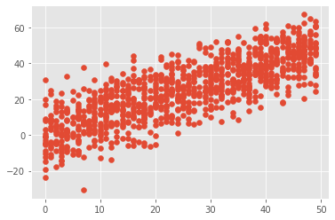

```python
import matplotlib
import matplotlib.pyplot as plt
%matplotlib inline
matplotlib.style.use('ggplot')
plt.scatter(x, y)
plt.show()
```

### Histograms and Distributions

A **histogram** displays the frequency of data occurrences in a bar graph. More specifically, it indicates how often each distinct value occurs in the dataset. The horizontal axis represents the values of the dataset and the vertical axis represents the number of times those values occur.

A histogram is a specific example of a **distribution**.

**Continuous distributions** allow *data to take on an infinite number of possible values*. Examples include:

- Normal
- Gamma
- Chi-squared
- Student's t
- Pareto
- etc.

Don't worry about what these distributions are yet - we will cover them later.

On the other hand, **discrete distributions** are those in which the *data can only be one of a finite set of values*. Histograms are discrete distributions because the possible values must come directly from the dataset from which they is created, which by definition must be a finite set. Other examples of discrete distributions include:

- Poisson
- Binomial
- Hypergeometric
- Bernoulli
- etc.

Again, don't worry about what these distributions are - we will cover them later.

[figure not shown]

More info about distributions [here](https://github.com/rasmusab/distribution_diagrams)

```python
# Descriptive Statistics with Python
import numpy as np
from scipy import stats
import pandas as pd

np.random.seed(42)
```

```python
data = np.random.randn(5, 4) # Normal Data
data
```

```
array([[ 0.49671415, -0.1382643 ,  0.64768854,  1.52302986],
       [-0.23415337, -0.23413696,  1.57921282,  0.76743473],
       [-0.46947439,  0.54256004, -0.46341769, -0.46572975],
       [ 0.24196227, -1.91328024, -1.72491783, -0.56228753],
       [-1.01283112,  0.31424733, -0.90802408, -1.4123037 ]])
```

```python
print("Mean All: " , np.mean(data))
print("Mean Column: " , np.mean(data,0))
print("Mean Row: " , np.mean(data,1))
print("Standard deviation: " , np.std(data))
print("Median: " , np.median(data))
print("Mode: ", mode(data)) # Mode by column and frequency
```

```
Mean All:  -0.17129856144182892
Mean Column:  [-0.19555649 -0.28577483 -0.17389165 -0.02997128]
Mean Row:  [ 0.63229206  0.4695893  -0.21401545 -0.98963083 -0.75472789]
Standard deviation:  0.9357199588937781
Median:  -0.23414516583625827
Mode:  ModeResult(mode=array([[-1.01283112, -1.91328024, -1.72491783, -1.4123037 ]]), count=array([[1, 1, 1, 1]]))
```

```python
# Correlation
np.corrcoef(data)
```

```
array([[ 1.        ,  0.51051246, -0.74954708,  0.43834633, -0.89985726],
       [ 0.51051246,  1.        , -0.53041766, -0.33865385, -0.47748587],
       [-0.74954708, -0.53041766,  1.        , -0.61023023,  0.956611  ],
       [ 0.43834633, -0.33865385, -0.61023023,  1.        , -0.64925683],
       [-0.89985726, -0.47748587,  0.956611  , -0.64925683,  1.        ]])
```

```python
# Correlation only 2 vectors
np.corrcoef(data[0], data[1])
```

```
array([[1.        , 0.51051246],
       [0.51051246, 1.        ]])
```

```python
# With pandas
dataframe = pd.DataFrame(data, index=['a', 'b', 'c', 'd', 'e'],
                        columns=['col1', 'col2', 'col3', 'col4'])
dataframe
```

|  | col1 | col2 | col3 | col4 |
| --- | --- | --- | --- | --- |
| a | 0.496714 | -0.138264 | 0.647689 | 1.523030 |
| b | -0.234153 | -0.234137 | 1.579213 | 0.767435 |
| c | -0.469474 | 0.542560 | -0.463418 | -0.465730 |
| d | 0.241962 | -1.913280 | -1.724918 | -0.562288 |
| e | -1.012831 | 0.314247 | -0.908024 | -1.412304 |

```python
# Statistics Summary
dataframe.describe()
```

|  | col1 | col2 | col3 | col4 |
| --- | --- | --- | --- | --- |
| count | 5.000000 | 5.000000 | 5.000000 | 5.000000 |
| mean | -0.195556 | -0.285775 | -0.173892 | -0.029971 |
| std | 0.594794 | 0.964283 | 1.301617 | 1.165307 |
| min | -1.012831 | -1.913280 | -1.724918 | -1.412304 |
| 25% | -0.469474 | -0.234137 | -0.908024 | -0.562288 |
| 50% | -0.234153 | -0.138264 | -0.463418 | -0.465730 |
| 75% | 0.241962 | 0.314247 | 0.647689 | 0.767435 |
| max | 0.496714 | 0.542560 | 1.579213 | 1.523030 |

### Normal distribution

The **normal distribution** is one of the most important distributions, since it is the one that most often approximates real-world phenomena. It has a "flared" shape and is symmetric:

```python
import matplotlib.pyplot as plt # importando matplotlib
import seaborn as sns # importando seaborn

# parametros esteticos de seaborn
sns.set_palette("deep", desat=.6)
sns.set_context(rc={"figure.figsize": (8, 4)})
```

```python
mu, sigma = 0, 0.1 # mean y standard deviation
s = np.random.normal(mu, sigma, 1000) # creating sample data
```

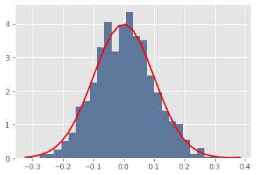

```python
# histogram
count, box, omit = plt.hist(s, 30, density=True)
normal = plt.plot(box, 1/(sigma * np.sqrt(2 * np.pi)) *
         np.exp( - (box - mu)**2 / (2 * sigma**2) ),
         linewidth=2, color='r')
```

### Symmetric and asymmetric distributions

As discussed, a normal distribution is **symmetric**. A distribution is symmetric when the mode, median, and mean are roughly equal. In more colloquial terms, the left and right halves of the distribution look identical, and both halves start with high "peaks" and taper off as one moves to the "tails".

[figure not shown]

A distribution is **right-skewed - Positive Skew** if the "tail" to the right of the mean is longer than the one to the left. In the same way, a distribution is **left-skewed - Negative Skew** if the "tail" to the left of the mean is longer than the one to the right. These are examples of **asymmetric** distributions.

[figure not shown]

Asymmetric distributions are often problematic, since most statistical methods are usually developed for normal distributions, which are symmetric. To overcome these problems, transformations are usually carried out on the data so that the resulting data more closely resembles a normal distribution. This will be discussed in more depth later.

Other measure is **kurtosis**:

*Excess kurtosis* is usually defined as kurt – 3, measure of the "peakedness" of the probability distribution of a real-valued random variable.

- Excess kurt for the normal distribution is 0 (i.e. 3 -3 = 0).
- Negative excess equals lighter tails than a normal distribution.
- Positive excess equals heavier tails than the normal.

[figure not shown]

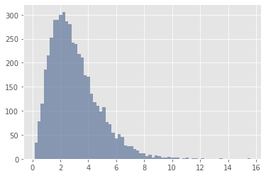

```python
# Gamma distribution - Right-skewed
x = stats.gamma(3).rvs(5000)
gamma = plt.hist(x, 70, histtype="stepfilled", alpha=.7)
```

```python
# Calculate skew with scipy
stats.skew(x)
```

```
1.1555694959904996
```

```python
stats.kurtosis(x)
```

```
2.1768186279814925
```

### Quartiles and boxplots

The **quartiles** are the three values of the statistical variable that divide a set of ordered data into four equal parts. Q1, Q2 and Q3 determine the values corresponding to 25%, 50% and 75% of the data. Q2 coincides with the median.

**Boxplots** present several important characteristics of a dataset, such as dispersion and symmetry, at the same time. Each box is created using the three quartiles, as well as the minimum and maximum values of the dataset. These graphs provide us with a wealth of information and are extremely useful for finding outliers and comparing datasets:

[figure not shown]

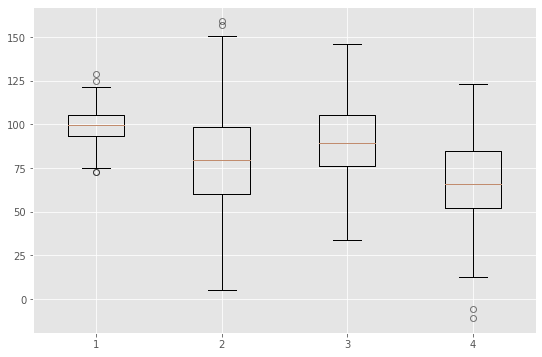

```python
data1 = np.random.normal(100, 10, 200)
data2 = np.random.normal(80, 30, 200)
data3 = np.random.normal(90, 20, 200)
data4 = np.random.normal(70, 25, 200)

data_graph = [data1, data2, data3, data4]


fig = plt.figure(1, figsize=(9, 6))
ax = fig.add_subplot(111)
bp = ax.boxplot(data_graph)

for flier in bp['fliers']:
    flier.set(marker='o', color='red', alpha=0.5)
```

## Basics of inferential statistics

### Linear regression

**Linear regression** is one of the main tools of inferential statistics. The goal of regression analysis is to describe the relationship between one variable, called the **dependent variable**, and another set of variables, called **independent variables**. More specifically, regression analysis helps to understand how the typical value of the dependent variable changes when any of the independent variables is changed, while the other independent variables remain fixed. The end product is an estimation of the dependent variable as a function of the independent variables. Based on this regression function, we can attempt to make estimates about future events.

Linear regression is one of the simplest and most widely used techniques in regression analysis; however, it makes very rigid assumptions about the relationship between the dependent variable $y$ and the independent variable $x$; namely:

$$y = \beta_0 + \beta_1 * x$$

One of the most popular methods to perform linear regression is **ordinary least squares (OLS)**.

```python
import statsmodels.formula.api as smf
import statsmodels.api as sm

df = pd.read_csv('Fish.csv')
df.head()
```

|  | Species | Weight | Length1 | Length2 | Length3 | Height | Width |
| --- | --- | --- | --- | --- | --- | --- | --- |
| 0 | Bream | 242.0 | 23.2 | 25.4 | 30.0 | 11.5200 | 4.0200 |
| 1 | Bream | 290.0 | 24.0 | 26.3 | 31.2 | 12.4800 | 4.3056 |
| 2 | Bream | 340.0 | 23.9 | 26.5 | 31.1 | 12.3778 | 4.6961 |
| 3 | Bream | 363.0 | 26.3 | 29.0 | 33.5 | 12.7300 | 4.4555 |
| 4 | Bream | 430.0 | 26.5 | 29.0 | 34.0 | 12.4440 | 5.1340 |

```python
df.corr()
```

|  | Weight | Length1 | Length2 | Length3 | Height | Width |
| --- | --- | --- | --- | --- | --- | --- |
| Weight | 1.000000 | 0.915712 | 0.918618 | 0.923044 | 0.724345 | 0.886507 |
| Length1 | 0.915712 | 1.000000 | 0.999517 | 0.992031 | 0.625378 | 0.867050 |
| Length2 | 0.918618 | 0.999517 | 1.000000 | 0.994103 | 0.640441 | 0.873547 |
| Length3 | 0.923044 | 0.992031 | 0.994103 | 1.000000 | 0.703409 | 0.878520 |
| Height | 0.724345 | 0.625378 | 0.640441 | 0.703409 | 1.000000 | 0.792881 |
| Width | 0.886507 | 0.867050 | 0.873547 | 0.878520 | 0.792881 | 1.000000 |

```python
df.shape
```

```
(159, 7)
```

```python
est = smf.ols(formula='Weight ~ Length3', data=df).fit()
est.summary()
```

OLS Regression Results

| Dep. Variable: | Weight | R-squared: | 0.852 |
| --- | --- | --- | --- |
| Model: | OLS | Adj. R-squared: | 0.851 |
| Method: | Least Squares | F-statistic: | 903.9 |
| Date: | Sat, 29 Aug 2020 | Prob (F-statistic): | 5.02e-67 |
| Time: | 16:20:08 | Log-Likelihood: | -1008.2 |
| No. Observations: | 159 | AIC: | 2020. |
| Df Residuals: | 157 | BIC: | 2027. |
| Df Model: | 1 |  |  |
| Covariance Type: | nonrobust |  |  |

|  | coef | std err | t | P>\|t\| | [0.025 | 0.975] |
| --- | --- | --- | --- | --- | --- | --- |
| Intercept | -490.4006 | 31.526 | -15.556 | 0.000 | -552.670 | -428.132 |
| Length3 | 28.4602 | 0.947 | 30.065 | 0.000 | 26.590 | 30.330 |

| Omnibus: | 2.876 | Durbin-Watson: | 0.415 |
| --- | --- | --- | --- |
| Prob(Omnibus): | 0.237 | Jarque-Bera (JB): | 2.439 |
| Skew: | -0.221 | Prob(JB): | 0.295 |
| Kurtosis: | 3.415 | Cond. No. | 95.9 |

Warnings:  
[1] Standard Errors assume that the covariance matrix of the errors is correctly specified.

There's quite a lot going on here in the output, so let's briefly explain what some of these mean:

- **Dep. Variable:** the variable that we are estimating
- **Model:** the model we are using
- **R-squared:** the coefficient of determination, which *measures how well our regression line approximates the real data*
- **Adj. R-squared:** R-squared adjusted according to the number of observations
- **[95.0% Conf. Int.]:** the lower and upper values of the 95% confidence interval
- **coef:** the estimated value of the coefficient
- **std err:** the standard error of the coefficient estimate
- **Skew:** a measure of the skewness/non-symmetry of the data about the mean
- **Kurtosis:** A measure of the shape of the distribution. The kurtosis compares the amount of data near the mean with that which is further from the mean (in the tails)

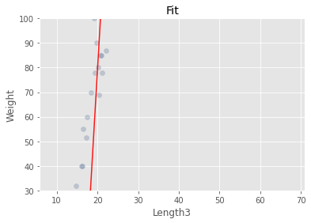

```python
y = df.Weight
X = df.Length3
X = sm.add_constant(X)

X_1 = pd.DataFrame({'Length3': np.linspace(X.Length3.min(), X.Length3.max(), 100)})
X_1 = sm.add_constant(X_1)

y_reg = est.predict(X_1)

plt.scatter(X.Length3, y, alpha=0.3)
plt.ylim(30, 100)
plt.xlabel("Length3")
plt.ylabel("Weight")
plt.title("Fit")
reg = plt.plot(X_1.Length3, y_reg, 'r', alpha=0.9)
```

### Hypothesis testing

**Hypothesis testing** is an essential procedure in statistics. A hypothesis test evaluates two mutually exclusive statements about a population to determine which statement is best supported by the sample data. When we say that a finding is *statistically significant*, it’s thanks to a hypothesis test.

The first hypothesis is generally called the **null hypothesis**, and is a general statement or default view that there is no relationship between two measured phenomena, or no association among groups. It can be thought of as a status-quo assumption. For example, "Company X's production equals 50 units/per day".

The **alternative hypothesis** is the second hypothesis, and is set at odds to the null hypothesis. It is usually taken to mean that the observed phenomena in the data are the result of a real, non-random effect. For example, "Company X's production is not equal to 50 units/per day".

[figure not shown]

In order to evaluate between these two hypotheses, we need to indicate a threshold **level of significance**. This is the probability that the observed results are actually due to chance, assuming the null hypothesis were true. Since we cannot ever 100% prove that the null hypothesis is false, we must select a level of significance that is small but nonzero. Generally, 5% is used (although in theory you can set any level you like). So if the computed probability that the observed results are due to chance is less than 5%, we reject the null hypothesis and propose the alternative hypothesis; otherwise, we do not.

There are two types of errors we can make in doing this:

1. **Type I Error:** Rejecting the null hypothesis when we should not. The probability of a Type I error is denoted by $\alpha$.
2. **Type II Error:** Failing to reject the null hypothesis when we should. The probability of a Type II error is denoted by $\beta$.

Finally, we come to the **$p$-value**, which is our calculated probability of observing the results that we do assuming the null hypothesis is true. As discussed earlier, if this is under the level of significance (usually 5%), then you can claim to have reasonable evidence to reject the null hypothesis. It does NOT automatically imply a "meaningful" or "important" finding, however - that is for you to decide when considering the real-world relevance of your result.

#### $t - test$

A t-test is used to determine if there is a significant difference between the means of two groups. It is mostly used when the data would likely follow a normal distribution, like the set of outcomes of flipping a coin 100 times.

*ttest_1samp*:

Calculate the T-test for the mean of ONE group of scores.

This is a two-sided test for the null hypothesis that the expected value (mean) of a sample of independent observations a is equal to the given population mean, popmean.

*ttest_ind*:

Calculate the T-test for the means of two independent samples of scores.

This is a two-sided test for the null hypothesis that 2 independent samples have identical average (expected) values. This test assumes that the populations have identical variances by default.

The One Sample t Test determines whether the sample mean is statistically different from a known or hypothesised population mean. The One Sample t Test is a parametric test

```python
from scipy.stats import ttest_1samp
import numpy as np

ages = [32,34,29,29,22,39,38,37,38,36,30,26,22,22]
print(ages)

ages_mean = np.mean(ages)
print(ages_mean)

tset, pval = ttest_1samp(ages, 30)
print("p-values: ",pval)

if pval < 0.05:    # alpha value is 0.05 or 5%
    print(" we are rejecting null hypothesis")
else:
    print("we are accepting null hypothesis")
```

```
[32, 34, 29, 29, 22, 39, 38, 37, 38, 36, 30, 26, 22, 22]
31.0
p-values:  0.5605155888171379
we are accepting null hypothesis
```

The Independent Samples t Test or 2-sample t-test compares the means of two independent groups in order to determine whether there is statistical evidence that the associated population means are significantly different. The Independent Samples t Test is a parametric test. This test is also known as: Independent t Test.

```python
weed_pd = pd.read_csv("Weed_Price.csv", parse_dates=[-1])
```

```python
weed_pd["month"] = weed_pd.date.apply(lambda x: x.month)
weed_pd["year"] = weed_pd.date.apply(lambda x: x.year)
```

```python
weed_pd.head()
```

|  | State | HighQ | HighQN | MedQ | MedQN | LowQ | LowQN | date | month | year |
| --- | --- | --- | --- | --- | --- | --- | --- | --- | --- | --- |
| 0 | Alabama | 339.06 | 1042 | 198.64 | 933 | 149.49 | 123 | 2014-01-01 | 1 | 2014 |
| 1 | Alaska | 288.75 | 252 | 260.60 | 297 | 388.58 | 26 | 2014-01-01 | 1 | 2014 |
| 2 | Arizona | 303.31 | 1941 | 209.35 | 1625 | 189.45 | 222 | 2014-01-01 | 1 | 2014 |
| 3 | Arkansas | 361.85 | 576 | 185.62 | 544 | 125.87 | 112 | 2014-01-01 | 1 | 2014 |
| 4 | California | 248.78 | 12096 | 193.56 | 12812 | 192.92 | 778 | 2014-01-01 | 1 | 2014 |

```python
# Let's work on weed prices in California in 2014
weed_ca_2014 = weed_pd[(weed_pd.State=="California") & (weed_pd.year==2014)]
```

```python
#Mean and standard deviation of high quality weed's price
print ("Mean:", weed_ca_2014.HighQ.mean())
print ("Standard Deviation:", weed_ca_2014.HighQ.std())
```

```
Mean: 245.89423076923077
Standard Deviation: 1.2899079393714108
```

```python
#Confidence interval on the mean
stats.norm.interval(0.95, loc=weed_ca_2014.HighQ.mean(), scale = weed_ca_2014.HighQ.std()/np.sqrt(len(weed_ca_2014)))
```

```
(245.7617184927259, 246.02674304573566)
```

```python
# Question: Are high-quality weed prices in Jan 2014 significantly higher than in Jan 2015?

#Get the data
weed_ca_jan2014 = np.array(weed_pd[(weed_pd.State=="California") & (weed_pd.year==2014) & (weed_pd.month==1)].HighQ)
weed_ca_jan2015 = np.array(weed_pd[(weed_pd.State=="California") & (weed_pd.year==2015) & (weed_pd.month==1)].HighQ)
```

```python
print ("Mean-2014 Jan:", weed_ca_jan2014.mean())
print ("Mean-2015 Jan:", weed_ca_jan2015.mean())
```

```
Mean-2014 Jan: 248.4454838709677
Mean-2015 Jan: 243.60225806451612
```

```python
print ("Effect size:", weed_ca_jan2014.mean() - weed_ca_jan2015.mean())
```

```
Effect size: 4.843225806451585
```

**Null Hypothesis**: Mean prices aren't significantly different

Perform **t-test** and determine the p-value.

```python
stats.ttest_ind(weed_ca_jan2014, weed_ca_jan2015, equal_var=True)
```

```
Ttest_indResult(statistic=98.01132523815805, pvalue=6.297971818508403e-68)
```

p-value is the probability that the effective size was by chance. And here, p-value is almost 0.

*Conclusion*: The price difference is significant. But is a price increase of $4.85 a big deal? The price decreased in 2015 by almost 2%. Always remember to look at effect size.

#### Chi-square test

We use the **chi-square test** when we have two categorical variables from a single population. It is used to determine whether there is a significant association between the two variables.

For example, in an election survey, voters might be classified by gender (male or female) and voting preference (Democrat, Republican, or Independent). We could use a chi-square test for independence to determine whether gender is related to voting preference:

```python
df_chi = pd.read_csv('chi-test.csv')

contingency_table=pd.crosstab(df_chi["Gender"],df_chi["Like Shopping?"])
print('contingency_table :\n',contingency_table)
```

```
contingency_table :
 Like Shopping?  No  Yes
Gender
Female           2    3
Male             2    2
```

```python
from scipy.stats import chi2

#Observed Values
Observed_Values = contingency_table.values
print("Observed Values :\n",Observed_Values)


b=stats.chi2_contingency(contingency_table)
Expected_Values = b[3]
print("Expected Values :\n",Expected_Values)


no_of_rows=len(contingency_table.iloc[0:2,0])
no_of_columns=len(contingency_table.iloc[0,0:2])
ddof=(no_of_rows-1)*(no_of_columns-1)
print("Degree of Freedom:-",ddof)

alpha = 0.05
chi_square=sum([(o-e)**2./e for o,e in zip(Observed_Values,Expected_Values)])
chi_square_statistic=chi_square[0]+chi_square[1]
print("chi-square statistic:-",chi_square_statistic)

critical_value=chi2.ppf(q=1-alpha,df=ddof)
print('critical_value:',critical_value)
```

```
Observed Values :
 [[2 3]
 [2 2]]
Expected Values :
 [[2.22222222 2.77777778]
 [1.77777778 2.22222222]]
Degree of Freedom:- 1
chi-square statistic:- 0.09000000000000008
critical_value: 3.841458820694124
```

```python
#p-value
p_value=1-chi2.cdf(x=chi_square_statistic,df=ddof)
print('p-value:',p_value)
print('Significance level: ',alpha)
print('Degree of Freedom: ',ddof)
print('chi-square statistic:',chi_square_statistic)
print('critical_value:',critical_value)
print('p-value:',p_value)

if chi_square_statistic>=critical_value:
    print("Reject H0,There is a relationship between 2 categorical variables")
else:
    print("Retain H0,There is no relationship between 2 categorical variables")

if p_value<=alpha:
    print("Reject H0,There is a relationship between 2 categorical variables")
else:
    print("Retain H0,There is no relationship between 2 categorical variables")
```

```
p-value: 0.7641771556220945
Significance level:  0.05
Degree of Freedom:  1
chi-square statistic: 0.09000000000000008
critical_value: 3.841458820694124
p-value: 0.7641771556220945
Retain H0,There is no relationship between 2 categorical variables
Retain H0,There is no relationship between 2 categorical variables
```

#### Chi-Square test for goodness fit

$$ \chi^2 = \sum (O - E)^2/E $$

- O is observed frequency
- E is expected frequency
- $ \chi $ is the chi-square statistic

Let's assume the proportion of people who bought High, Medium and Low quality weed in Jan-2014 as the expected proportion. Find if proportion of people who bought weed in Jan 2015 conformed to the norm

```python
weed_jan2014 = weed_pd[(weed_pd.year==2014) & (weed_pd.month==1)][["HighQN", "MedQN", "LowQN"]]
weed_jan2015 = weed_pd[(weed_pd.year==2015) & (weed_pd.month==1)][["HighQN", "MedQN", "LowQN"]]
```

```python
weed_jan2014.head()
```

|  | HighQN | MedQN | LowQN |
| --- | --- | --- | --- |
| 0 | 1042 | 933 | 123 |
| 1 | 252 | 297 | 26 |
| 2 | 1941 | 1625 | 222 |
| 3 | 576 | 544 | 112 |
| 4 | 12096 | 12812 | 778 |

```python
weed_jan2015.head()
```

|  | HighQN | MedQN | LowQN |
| --- | --- | --- | --- |
| 51 | 1539 | 1463 | 182 |
| 52 | 350 | 475 | 37 |
| 53 | 2638 | 2426 | 306 |
| 54 | 846 | 836 | 145 |
| 55 | 16512 | 19151 | 1096 |

```python
Expected = np.array(weed_jan2014.apply(sum, axis=0))
Observed = np.array(weed_jan2015.apply(sum, axis=0))
```

```python
print ("Expected:", Expected, "\n" , "Observed:", Observed)
```

```
Expected: [2918004 2644757  263958]
 Observed: [4057716 4035049  358088]
```

```python
print ("Expected:", Expected/np.sum(Expected.astype(float)), "\n" , "Observed:", Observed/np.sum(Observed.astype(float)))
```

```
Expected: [0.5007971  0.45390159 0.04530131]
 Observed: [0.48015461 0.47747239 0.042373  ]
```

```python
stats.chisquare(Observed, Expected)
```

```
Power_divergenceResult(statistic=1209562.2775169075, pvalue=0.0)
```

*Inference* : We reject null hypothesis. The proportions in Jan 2015 is different than what was expected.